# Scoring Dashboard: Model Evaluation & Drift Analysis

**Purpose:** Evaluate trained models on point-in-time holdout data and analyze distribution drift.

**What you'll learn:**

- How models perform on truly unseen data (not random holdout)
- Distribution drift between training and scoring populations
- Side-by-side comparison of validation vs scoring metrics
- Actionable recommendations based on drift analysis

## 1. Setup

**Show/Hide Code**

```python
import sys
from pathlib import Path

# Get the directory containing this notebook
# Works whether run from VS Code (cwd=project root) or from the scoring folder
_notebook_dir = Path(__file__).parent if '__file__' in dir() else Path.cwd()
if _notebook_dir.name != 'scoring':
    # Running from project root or elsewhere - find the config directory
    _config_dir = _notebook_dir / "generated_pipelines" / "local" / "customer_churn"
    if not _config_dir.exists():
        _config_dir = Path.cwd() / "generated_pipelines" / "local" / "customer_churn"
else:
    _config_dir = _notebook_dir.parent

sys.path.insert(0, str(_config_dir))

import pandas as pd
import numpy as np
import mlflow
import matplotlib.pyplot as plt
from sklearn.preprocessing import LabelEncoder
from sklearn.metrics import (roc_auc_score, average_precision_score, f1_score,
                             precision_score, recall_score, accuracy_score,
                             confusion_matrix, roc_curve, precision_recall_curve)
from IPython.display import display, HTML

from config import (PIPELINE_NAME, TARGET_COLUMN, MLFLOW_TRACKING_URI,
                    FEAST_ENTITY_KEY, PROJECT_ROOT, RECOMMENDATIONS_HASH)

# Set MLflow tracking URI immediately to prevent default ./mlruns creation
mlflow.set_tracking_uri(MLFLOW_TRACKING_URI)

print(f"Project root: {PROJECT_ROOT}")
print(f"MLflow URI: {MLFLOW_TRACKING_URI}")

SNAPSHOT_DIR = PROJECT_ROOT / "experiments" / "findings" / "snapshots"
PREDICTIONS_PATH = PROJECT_ROOT / "data" / "scoring" / "predictions.parquet"
ORIGINAL_DATA_PATH = PROJECT_ROOT / "tests" / "fixtures" / "customer_retention_retail.csv"
```

```
Project root: /Users/Vital/python/CustomerRetention
MLflow URI: /Users/Vital/python/CustomerRetention/experiments/mlruns
```

## 2. Load Data

**Show/Hide Code**

```python
def get_latest_snapshot():
    snapshots = sorted(SNAPSHOT_DIR.glob("training_v*.parquet"), key=lambda p: p.stat().st_mtime, reverse=True)
    return pd.read_parquet(snapshots[0]), snapshots[0].name

training_df, snapshot_name = get_latest_snapshot()
scoring_df = pd.read_parquet(PREDICTIONS_PATH)

print(f"Training snapshot: {snapshot_name} ({len(training_df):,} records)")
print(f"Scoring holdout: {len(scoring_df):,} records")
print(f"\nTarget distribution:")
print(f"  Training: {training_df['target'].mean():.1%} retained")
print(f"  Scoring:  {scoring_df['actual'].mean():.1%} retained")
```

```
Training snapshot: training_v38.parquet (26,578 records)
Scoring holdout: 4,198 records

Target distribution:
  Training: 78.4% retained
  Scoring:  86.4% retained
```

## 3. Load All Models from MLflow

**Show/Hide Code**

```python
# Load models directly from model registry artifacts
import os
import pickle
import yaml

print(f"Current working directory: {os.getcwd()}")
print(f"MLflow tracking URI: {MLFLOW_TRACKING_URI}")
print(f"URI exists: {Path(MLFLOW_TRACKING_URI).exists()}")

client = mlflow.tracking.MlflowClient()
experiment = client.get_experiment_by_name(PIPELINE_NAME)

if experiment is None:
    raise RuntimeError(f"Experiment '{PIPELINE_NAME}' not found!")

print(f"Experiment found: {experiment.name} (ID: {experiment.experiment_id})")

# Find models with actual artifacts in the models directory
models_dir = Path(MLFLOW_TRACKING_URI) / experiment.experiment_id / "models"
MODEL_TYPES = ["logistic_regression", "random_forest", "xgboost"]
models = {}

# Find the latest model with artifacts for each type
for model_type in MODEL_TYPES:
    best_model_dir = None
    best_timestamp = 0

    for model_dir in models_dir.glob("m-*"):
        meta_file = model_dir / "meta.yaml"
        artifacts_dir = model_dir / "artifacts"
        model_file = artifacts_dir / "model.pkl"

        if meta_file.exists() and model_file.exists():
            with open(meta_file) as f:
                meta = yaml.safe_load(f)

            if model_type in meta.get("name", ""):
                timestamp = meta.get("creation_timestamp", 0)
                if timestamp > best_timestamp:
                    best_timestamp = timestamp
                    best_model_dir = model_dir

    if best_model_dir:
        model_file = best_model_dir / "artifacts" / "model.pkl"
        with open(model_file, "rb") as f:
            model = pickle.load(f)

        # Get metrics from the source run
        meta_file = best_model_dir / "meta.yaml"
        with open(meta_file) as f:
            meta = yaml.safe_load(f)
        source_run_id = meta.get("source_run_id", "")

        try:
            run = client.get_run(source_run_id)
            metrics = run.data.metrics
        except:
            metrics = {}

        models[model_type] = {
            "model": model,
            "run_id": source_run_id,
            "metrics": metrics,
            "model_name": meta.get("name", "")
        }
        print(f"  Loaded {model_type} from {meta.get('name', 'unknown')}")
    else:
        print(f"  No artifacts found for {model_type}")

print(f"\nLoaded {len(models)} models")

if not models:
    print("\nWARNING: No models could be loaded!")
    print("You may need to re-run the training pipeline to generate model artifacts.")
```

```
Current working directory: /Users/Vital/python/CustomerRetention/generated_pipelines/local/customer_churn/scoring
MLflow tracking URI: /Users/Vital/python/CustomerRetention/experiments/mlruns
URI exists: True
Experiment found: customer_churn (ID: 600981863403149336)
  Loaded logistic_regression from model_logistic_regression_2b70dc33
```

```
  Loaded random_forest from model_random_forest_2b70dc33
  Loaded xgboost from model_xgboost_2b70dc33

Loaded 3 models
```

## 4. Prepare Features for Scoring

**Show/Hide Code**

```python
def get_model_feature_names(model):
    """Get feature names from trained model."""
    if hasattr(model, 'feature_names_in_'):
        return list(model.feature_names_in_)
    elif hasattr(model, 'feature_name_'):
        return model.feature_name_()
    elif hasattr(model, 'get_booster'):
        return model.get_booster().feature_names
    return None

def prepare_features_for_model(df, model):
    """Prepare features aligned with model's expected feature order."""
    feature_names = get_model_feature_names(model)

    if feature_names is None:
        raise ValueError("Could not determine feature names from model")

    result = pd.DataFrame(index=df.index)

    for col in feature_names:
        if col in df.columns:
            if df[col].dtype == 'object' or df[col].dtype.name == 'category':
                result[col] = LabelEncoder().fit_transform(df[col].astype(str))
            else:
                result[col] = df[col].fillna(0)
        else:
            result[col] = 0

    return result[feature_names]

# Check if models were loaded
if not models:
    raise RuntimeError(
        "No models were loaded from MLflow!\n"
        "Please check the output from cell 3 (Load Models) for errors.\n"
        "Common issues:\n"
        "  - MLflow tracking URI path doesn't exist\n"
        "  - Experiment not found\n"
        "  - No runs with 'best_model' tag"
    )

# Get feature names from first loaded model (all should have same features)
first_model = list(models.values())[0]["model"]
feature_names = get_model_feature_names(first_model)
print(f"Model expects {len(feature_names)} features: {feature_names}")
```

```
Model expects 13 features: ['created', 'firstorder', 'lastorder', 'esent', 'eopenrate', 'eclickrate', 'avgorder', 'ordfreq', 'paperless', 'refill', 'doorstep', 'favday', 'city']
```

## 5. Evaluate All Models on Scoring Data

**Show/Hide Code**

```python
from sklearn.dummy import DummyClassifier

def evaluate_model(model, X, y_true):
    """Evaluate model with aligned features."""
    y_proba = model.predict_proba(X)[:, 1] if hasattr(model, 'predict_proba') else model.predict(X)
    y_pred = (y_proba >= 0.5).astype(int)
    return {
        "y_pred": y_pred,
        "y_proba": y_proba,
        "roc_auc": roc_auc_score(y_true, y_proba),
        "pr_auc": average_precision_score(y_true, y_proba),
        "f1": f1_score(y_true, y_pred),
        "precision": precision_score(y_true, y_pred),
        "recall": recall_score(y_true, y_pred),
        "accuracy": accuracy_score(y_true, y_pred)
    }

y_scoring = scoring_df["actual"].values
scoring_results = {}

# Evaluate trained models
for name, data in models.items():
    model = data["model"]
    X_scoring = prepare_features_for_model(scoring_df, model)
    scoring_results[name] = evaluate_model(model, X_scoring, y_scoring)
    print(f"{name}: ROC-AUC={scoring_results[name]['roc_auc']:.4f}, F1={scoring_results[name]['f1']:.4f}")

# Add Naive (Dummy) Classifier as baseline
# Uses actual class distribution - predicts P(retained) = observed retention rate
# This represents a "no-skill" model that only knows the class proportions
X_scoring_first = prepare_features_for_model(scoring_df, first_model)
retention_rate = y_scoring.mean()  # Actual proportion of retained customers
print(f"\nActual class distribution: {retention_rate:.1%} retained, {1-retention_rate:.1%} churned")

# Create dummy classifier that uses prior probabilities (class distribution)
dummy_clf = DummyClassifier(strategy='prior', random_state=42)
dummy_clf.fit(X_scoring_first, y_scoring)
scoring_results["naive_baseline"] = evaluate_model(dummy_clf, X_scoring_first, y_scoring)
print(f"naive_baseline: ROC-AUC={scoring_results['naive_baseline']['roc_auc']:.4f}, F1={scoring_results['naive_baseline']['f1']:.4f}")
print(f"  (Predicts {retention_rate:.1%} probability for all samples)")
```

```
logistic_regression: ROC-AUC=0.9441, F1=0.9670
random_forest: ROC-AUC=0.9073, F1=0.9660
xgboost: ROC-AUC=0.9142, F1=0.9684

Actual class distribution: 86.4% retained, 13.6% churned
naive_baseline: ROC-AUC=0.5000, F1=0.9270
  (Predicts 86.4% probability for all samples)
```

## 6. Model Comparison: Validation vs Scoring

Side-by-side comparison of metrics from 11% validation split vs point-in-time scoring holdout.

**Show/Hide Code**

```python
# Always show all 3 model types in comparison
MODEL_TYPES_DISPLAY = ["logistic_regression", "random_forest", "xgboost"]
comparison_data = []

for model_type in MODEL_TYPES_DISPLAY:
    if model_type in models:
        val_metrics = models[model_type]["metrics"]
        score_metrics = scoring_results[model_type]
        comparison_data.append({
            "Model": model_type.replace("_", " ").title(),
            "Val ROC-AUC": val_metrics.get("roc_auc", 0),
            "Score ROC-AUC": score_metrics["roc_auc"],
            "AUC Gap": val_metrics.get("roc_auc", 0) - score_metrics["roc_auc"],
            "Val F1": val_metrics.get("f1", 0),
            "Score F1": score_metrics["f1"],
            "F1 Gap": val_metrics.get("f1", 0) - score_metrics["f1"],
            "Val Precision": val_metrics.get("precision", 0),
            "Score Precision": score_metrics["precision"],
            "Val Recall": val_metrics.get("recall", 0),
            "Score Recall": score_metrics["recall"]
        })
    else:
        # Model not available
        comparison_data.append({
            "Model": model_type.replace("_", " ").title(),
            "Val ROC-AUC": np.nan,
            "Score ROC-AUC": np.nan,
            "AUC Gap": np.nan,
            "Val F1": np.nan,
            "Score F1": np.nan,
            "F1 Gap": np.nan,
            "Val Precision": np.nan,
            "Score Precision": np.nan,
            "Val Recall": np.nan,
            "Score Recall": np.nan
        })

# Add naive baseline (uses actual class distribution as prediction)
naive_metrics = scoring_results["naive_baseline"]
retention_rate = y_scoring.mean()
comparison_data.append({
    "Model": f"Naive Baseline ({retention_rate:.0%})",
    "Val ROC-AUC": 0.5,  # No-skill ROC-AUC
    "Score ROC-AUC": naive_metrics["roc_auc"],
    "AUC Gap": 0,
    "Val F1": naive_metrics["f1"],
    "Score F1": naive_metrics["f1"],
    "F1 Gap": 0,
    "Val Precision": naive_metrics["precision"],
    "Score Precision": naive_metrics["precision"],
    "Val Recall": naive_metrics["recall"],
    "Score Recall": naive_metrics["recall"]
})

comparison_df = pd.DataFrame(comparison_data).round(4)
print("=" * 100)
print("MODEL COMPARISON: VALIDATION (11%) vs SCORING (POINT-IN-TIME HOLDOUT)")
print("=" * 100)
display(comparison_df)
```

```
====================================================================================================
MODEL COMPARISON: VALIDATION (11%) vs SCORING (POINT-IN-TIME HOLDOUT)
====================================================================================================
```

|  | Model | Val ROC-AUC | Score ROC-AUC | AUC Gap | Val F1 | Score F1 | F1 Gap | Val Precision | Score Precision | Val Recall | Score Recall |
| --- | --- | --- | --- | --- | --- | --- | --- | --- | --- | --- | --- |
| 0 | Logistic Regression | 0.9678 | 0.9441 | 0.0237 | 0.9675 | 0.9670 | 0.0006 | 0.9596 | 0.9387 | 0.9756 | 0.9970 |
| 1 | Random Forest | 0.9830 | 0.9073 | 0.0757 | 0.9804 | 0.9660 | 0.0144 | 0.9685 | 0.9350 | 0.9926 | 0.9992 |
| 2 | Xgboost | 0.9854 | 0.9142 | 0.0712 | 0.9790 | 0.9684 | 0.0106 | 0.9712 | 0.9423 | 0.9869 | 0.9959 |
| 3 | Naive Baseline (86%) | 0.5000 | 0.5000 | 0.0000 | 0.9270 | 0.9270 | 0.0000 | 0.8640 | 0.8640 | 1.0000 | 1.0000 |

**Show/Hide Code**

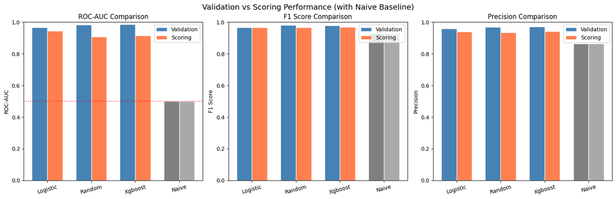

```python
fig, axes = plt.subplots(1, 3, figsize=(16, 5))

model_names = [d["Model"] for d in comparison_data]
x = np.arange(len(model_names))
width = 0.35

metrics_to_plot = [("Val ROC-AUC", "Score ROC-AUC", "ROC-AUC"),
                   ("Val F1", "Score F1", "F1 Score"),
                   ("Val Precision", "Score Precision", "Precision")]

# Colors: trained models in blue/coral, naive baseline in gray
n_trained = len(MODEL_TYPES_DISPLAY)
bar_colors_val = ['steelblue'] * n_trained + ['gray']
bar_colors_score = ['coral'] * n_trained + ['darkgray']

for ax, (val_col, score_col, title) in zip(axes, metrics_to_plot):
    val_vals = [d[val_col] if not pd.isna(d[val_col]) else 0 for d in comparison_data]
    score_vals = [d[score_col] if not pd.isna(d[score_col]) else 0 for d in comparison_data]

    # Plot bars with different colors for baseline
    for i, (v_val, s_val) in enumerate(zip(val_vals, score_vals)):
        # Skip if model not available (NaN)
        if pd.isna(comparison_data[i].get("Score ROC-AUC")) and i < n_trained:
            ax.bar(x[i] - width/2, 0, width, color='lightgray', edgecolor='white', hatch='//')
            ax.bar(x[i] + width/2, 0, width, color='lightgray', edgecolor='white', hatch='//')
            ax.text(x[i], 0.05, 'N/A', ha='center', fontsize=9, color='gray')
        else:
            ax.bar(x[i] - width/2, v_val, width, color=bar_colors_val[i],
                   label='Validation' if i == 0 else '', edgecolor='white')
            ax.bar(x[i] + width/2, s_val, width, color=bar_colors_score[i],
                   label='Scoring' if i == 0 else '', edgecolor='white')

    ax.set_ylabel(title)
    ax.set_xticks(x)
    # Shorter labels for x-axis
    short_names = []
    for name in model_names:
        if "Naive" in name:
            short_names.append("Naive")
        else:
            short_names.append(name.split()[0])
    ax.set_xticklabels(short_names, rotation=15)
    ax.legend()
    ax.set_ylim(0, 1.0)
    ax.set_title(f"{title} Comparison")

    # Add horizontal line at 0.5 for ROC-AUC (random baseline reference)
    if title == "ROC-AUC":
        ax.axhline(y=0.5, color='red', linestyle=':', alpha=0.7)

plt.tight_layout()
plt.suptitle("Validation vs Scoring Performance (with Naive Baseline)", y=1.02, fontsize=14)
plt.show()
```

## 7. Model Comparison Grid (Confusion Matrix, ROC, PR Curves)

**Show/Hide Code**

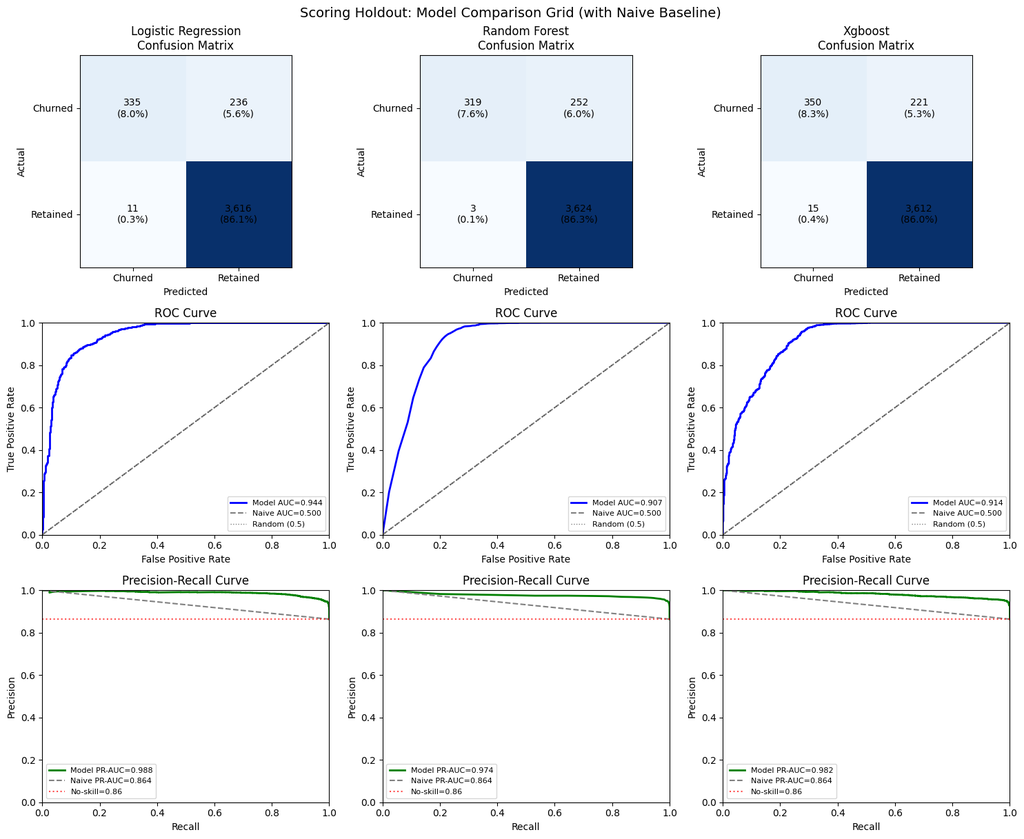

```
======================================================================
LIFT OVER NAIVE BASELINE
======================================================================
  logistic_regression  ROC-AUC lift: +0.4441  |  PR-AUC lift: +0.1239
  random_forest        ROC-AUC lift: +0.4073  |  PR-AUC lift: +0.1105
  xgboost              ROC-AUC lift: +0.4142  |  PR-AUC lift: +0.1179
```

```python
# Get naive baseline results for comparison curves
naive_results = scoring_results["naive_baseline"]
naive_fpr, naive_tpr, _ = roc_curve(y_scoring, naive_results["y_proba"])
naive_precision_curve, naive_recall_curve, _ = precision_recall_curve(y_scoring, naive_results["y_proba"])

# Always show 3 columns for the 3 model types
MODEL_TYPES_DISPLAY = ["logistic_regression", "random_forest", "xgboost"]
n_models = len(MODEL_TYPES_DISPLAY)
fig, axes = plt.subplots(3, n_models, figsize=(5*n_models, 12))

for i, model_type in enumerate(MODEL_TYPES_DISPLAY):
    if model_type in scoring_results:
        results = scoring_results[model_type]
        y_pred, y_proba = results["y_pred"], results["y_proba"]

        # Confusion Matrix
        cm = confusion_matrix(y_scoring, y_pred)
        ax_cm = axes[0, i]
        im = ax_cm.imshow(cm, cmap='Blues')
        ax_cm.set_xticks([0, 1])
        ax_cm.set_yticks([0, 1])
        ax_cm.set_xticklabels(['Churned', 'Retained'])
        ax_cm.set_yticklabels(['Churned', 'Retained'])
        ax_cm.set_xlabel('Predicted')
        ax_cm.set_ylabel('Actual')
        for ii in range(2):
            for jj in range(2):
                ax_cm.text(jj, ii, f"{cm[ii,jj]:,}\n({cm[ii,jj]/cm.sum()*100:.1f}%)",
                          ha='center', va='center', fontsize=10)
        ax_cm.set_title(f"{model_type.replace('_', ' ').title()}\nConfusion Matrix")

        # ROC Curve with naive baseline
        fpr, tpr, _ = roc_curve(y_scoring, y_proba)
        ax_roc = axes[1, i]
        ax_roc.plot(fpr, tpr, 'b-', lw=2, label=f"Model AUC={results['roc_auc']:.3f}")
        ax_roc.plot(naive_fpr, naive_tpr, 'gray', lw=1.5, linestyle='--',
                    label=f"Naive AUC={naive_results['roc_auc']:.3f}")
        ax_roc.plot([0, 1], [0, 1], 'k:', lw=1, alpha=0.5, label='Random (0.5)')
        ax_roc.set_xlabel('False Positive Rate')
        ax_roc.set_ylabel('True Positive Rate')
        ax_roc.set_title('ROC Curve')
        ax_roc.legend(loc='lower right', fontsize=8)
        ax_roc.set_xlim([0, 1])
        ax_roc.set_ylim([0, 1])

        # PR Curve with naive baseline
        precision_curve, recall_curve, _ = precision_recall_curve(y_scoring, y_proba)
        ax_pr = axes[2, i]
        ax_pr.plot(recall_curve, precision_curve, 'g-', lw=2,
                   label=f"Model PR-AUC={results['pr_auc']:.3f}")
        ax_pr.plot(naive_recall_curve, naive_precision_curve, 'gray', lw=1.5, linestyle='--',
                   label=f"Naive PR-AUC={naive_results['pr_auc']:.3f}")
        ax_pr.axhline(y=y_scoring.mean(), color='r', linestyle=':', alpha=0.7,
                      label=f"No-skill={y_scoring.mean():.2f}")
        ax_pr.set_xlabel('Recall')
        ax_pr.set_ylabel('Precision')
        ax_pr.set_title('Precision-Recall Curve')
        ax_pr.legend(loc='lower left', fontsize=8)
        ax_pr.set_xlim([0, 1])
        ax_pr.set_ylim([0, 1])
    else:
        # Model not available - show placeholder
        for row in range(3):
            ax = axes[row, i]
            ax.text(0.5, 0.5, f"{model_type.replace('_', ' ').title()}\n\nModel not available\n(no artifacts)",
                   ha='center', va='center', fontsize=12, color='gray',
                   transform=ax.transAxes)
            ax.set_xticks([])
            ax.set_yticks([])
            ax.spines['top'].set_visible(False)
            ax.spines['right'].set_visible(False)
            ax.spines['bottom'].set_visible(False)
            ax.spines['left'].set_visible(False)

plt.tight_layout()
plt.suptitle("Scoring Holdout: Model Comparison Grid (with Naive Baseline)", y=1.01, fontsize=14)
plt.show()

# Print lift over naive baseline
print("\n" + "=" * 70)
print("LIFT OVER NAIVE BASELINE")
print("=" * 70)
for model_type in MODEL_TYPES_DISPLAY:
    if model_type in scoring_results:
        results = scoring_results[model_type]
        roc_lift = results['roc_auc'] - naive_results['roc_auc']
        pr_lift = results['pr_auc'] - naive_results['pr_auc']
        print(f"  {model_type:20} ROC-AUC lift: +{roc_lift:.4f}  |  PR-AUC lift: +{pr_lift:.4f}")
    else:
        print(f"  {model_type:20} (not available)")
```

## 8. Distribution Drift Analysis

Compare feature distributions between training snapshot and scoring holdout.

**Show/Hide Code**

```python
# Get numeric features that exist in both training and scoring data
NUMERIC_FEATURES = ['esent', 'eopenrate', 'eclickrate', 'avgorder', 'ordfreq']
available_numeric = [f for f in NUMERIC_FEATURES if f in training_df.columns and f in scoring_df.columns]

drift_data = []
for col in available_numeric:
    train_mean, train_std = training_df[col].mean(), training_df[col].std()
    score_mean, score_std = scoring_df[col].mean(), scoring_df[col].std()
    drift_pct = (score_mean - train_mean) / train_mean * 100 if train_mean != 0 else 0
    z_score = abs(score_mean - train_mean) / train_std if train_std > 0 else 0
    drift_data.append({
        "Feature": col,
        "Train Mean": train_mean,
        "Train Std": train_std,
        "Score Mean": score_mean,
        "Score Std": score_std,
        "Drift %": drift_pct,
        "Z-Score": z_score,
        "Significant": "⚠️ YES" if (abs(drift_pct) > 20 or z_score > 2) else "No"
    })

target_col = 'target' if 'target' in training_df.columns else TARGET_COLUMN
train_retention = training_df[target_col].mean()
score_retention = scoring_df['actual'].mean()
drift_data.append({
    "Feature": "TARGET (retention)",
    "Train Mean": train_retention,
    "Train Std": 0,
    "Score Mean": score_retention,
    "Score Std": 0,
    "Drift %": (score_retention - train_retention) / train_retention * 100,
    "Z-Score": 0,
    "Significant": "⚠️ YES" if abs(score_retention - train_retention) > 0.05 else "No"
})

drift_df = pd.DataFrame(drift_data).round(3)
print("=" * 90)
print("DISTRIBUTION DRIFT ANALYSIS: TRAINING vs SCORING")
print("=" * 90)
display(drift_df)
```

```
==========================================================================================
DISTRIBUTION DRIFT ANALYSIS: TRAINING vs SCORING
==========================================================================================
```

|  | Feature | Train Mean | Train Std | Score Mean | Score Std | Drift % | Z-Score | Significant |
| --- | --- | --- | --- | --- | --- | --- | --- | --- |
| 0 | esent | 27.930 | 16.943 | 29.444 | 15.413 | 5.419 | 0.089 | No |
| 1 | eopenrate | 24.555 | 29.290 | 31.876 | 30.428 | 29.816 | 0.250 | ⚠️ YES |
| 2 | eclickrate | 5.348 | 10.230 | 7.727 | 12.279 | 44.473 | 0.232 | ⚠️ YES |
| 3 | avgorder | 62.470 | 41.835 | 57.870 | 34.518 | -7.364 | 0.110 | No |
| 4 | ordfreq | 0.038 | 0.104 | 0.036 | 0.105 | -6.136 | 0.023 | No |
| 5 | TARGET (retention) | 0.784 | 0.000 | 0.864 | 0.000 | 10.256 | 0.000 | ⚠️ YES |

**Show/Hide Code**

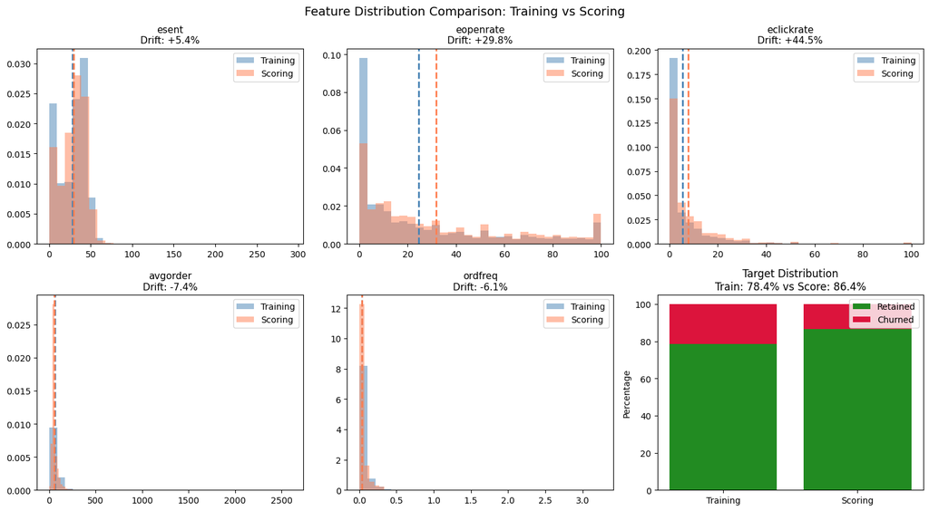

```python
n_plots = len(available_numeric) + 1  # +1 for target
n_cols = 3
n_rows = (n_plots + n_cols - 1) // n_cols
fig, axes = plt.subplots(n_rows, n_cols, figsize=(15, 4*n_rows))
axes = axes.flatten()

for i, col in enumerate(available_numeric):
    ax = axes[i]
    ax.hist(training_df[col].dropna(), bins=30, alpha=0.5, label='Training', color='steelblue', density=True)
    ax.hist(scoring_df[col].dropna(), bins=30, alpha=0.5, label='Scoring', color='coral', density=True)
    ax.axvline(training_df[col].mean(), color='steelblue', linestyle='--', lw=2)
    ax.axvline(scoring_df[col].mean(), color='coral', linestyle='--', lw=2)
    drift_info = next((d for d in drift_data if d["Feature"] == col), None)
    title = f"{col}\nDrift: {drift_info['Drift %']:+.1f}%" if drift_info else col
    ax.set_title(title, fontsize=11)
    ax.legend()

# Target distribution
ax = axes[len(available_numeric)]
categories = ['Training', 'Scoring']
retained = [train_retention * 100, score_retention * 100]
churned = [(1-train_retention) * 100, (1-score_retention) * 100]
ax.bar(categories, retained, label='Retained', color='forestgreen')
ax.bar(categories, churned, bottom=retained, label='Churned', color='crimson')
ax.set_ylabel('Percentage')
ax.set_title(f"Target Distribution\nTrain: {train_retention:.1%} vs Score: {score_retention:.1%}")
ax.legend()

# Hide empty axes
for j in range(len(available_numeric) + 1, len(axes)):
    axes[j].set_visible(False)

plt.tight_layout()
plt.suptitle("Feature Distribution Comparison: Training vs Scoring", y=1.02, fontsize=14)
plt.show()
```

## 9. Interpretation & Recommendations

**Show/Hide Code**

```python
significant_drift = [d for d in drift_data if "YES" in d["Significant"]]
best_model = max(scoring_results.items(), key=lambda x: x[1]["roc_auc"])
best_val_auc = models[best_model[0]]["metrics"].get("roc_auc", 0)
best_score_auc = best_model[1]["roc_auc"]
auc_gap = best_val_auc - best_score_auc

print("=" * 90)
print("INTERPRETATION & RECOMMENDATIONS")
print("=" * 90)

print(f"\n📊 BEST MODEL: {best_model[0].replace('_', ' ').title()}")
print(f"   Validation ROC-AUC: {best_val_auc:.4f}")
print(f"   Scoring ROC-AUC:    {best_score_auc:.4f}")
print(f"   Performance Gap:    {auc_gap:.4f} ({auc_gap/best_val_auc*100:.1f}% degradation)")

print(f"\n⚠️  DRIFT DETECTED IN {len(significant_drift)} FEATURES:")
for d in significant_drift:
    print(f"   • {d['Feature']}: {d['Drift %']:+.1f}% drift")

print("\n" + "=" * 90)
print("DIAGNOSIS")
print("=" * 90)

if auc_gap > 0.15:
    severity = "SEVERE"
elif auc_gap > 0.08:
    severity = "MODERATE"
else:
    severity = "ACCEPTABLE"

print(f"\n   Performance degradation: {severity}")

email_drift = [d for d in significant_drift if d["Feature"] in ["eopenrate", "eclickrate"]]
target_drift = [d for d in significant_drift if "TARGET" in d["Feature"]]

if email_drift:
    print("\n   ROOT CAUSE: Email engagement drift")
    print("   The scoring population shows significantly higher email engagement.")
    print("   This suggests the scoring customers are more active/engaged.")

if target_drift:
    print("\n   ROOT CAUSE: Target distribution shift")
    print(f"   Scoring has {score_retention:.1%} retention vs {train_retention:.1%} in training.")
    print("   The scoring population is inherently more likely to be retained.")

print("\n" + "=" * 90)
print("RECOMMENDATIONS")
print("=" * 90)

print("\n   1. RECALIBRATE MODEL")
print("      Adjust probability thresholds for the scoring population.")
print("      Current threshold of 0.5 may be too aggressive.")

print("\n   2. MONITOR DRIFT IN PRODUCTION")
print("      Implement automated drift detection for eopenrate, eclickrate.")
print("      Trigger model retraining when drift exceeds thresholds.")

print("\n   3. CONSIDER DOMAIN ADAPTATION")
print("      Train on data that includes more recent time periods.")
print("      Use sample weighting to emphasize patterns similar to scoring.")

print("\n   4. STRATIFIED EVALUATION")
print("      Evaluate model separately for high vs low engagement segments.")
print("      Consider segment-specific models if gap persists.")

print("\n   5. EXPECTED PRODUCTION PERFORMANCE")
print(f"      Based on scoring results, expect ROC-AUC of ~{best_score_auc:.2f} in production.")
print(f"      This is {'acceptable' if best_score_auc > 0.75 else 'concerning'} for business use.")
```

```
==========================================================================================
INTERPRETATION & RECOMMENDATIONS
==========================================================================================

📊 BEST MODEL: Logistic Regression
   Validation ROC-AUC: 0.9678
   Scoring ROC-AUC:    0.9441
   Performance Gap:    0.0237 (2.4% degradation)

⚠️  DRIFT DETECTED IN 3 FEATURES:
   • eopenrate: +29.8% drift
   • eclickrate: +44.5% drift
   • TARGET (retention): +10.3% drift

==========================================================================================
DIAGNOSIS
==========================================================================================

   Performance degradation: ACCEPTABLE

   ROOT CAUSE: Email engagement drift
   The scoring population shows significantly higher email engagement.
   This suggests the scoring customers are more active/engaged.

   ROOT CAUSE: Target distribution shift
   Scoring has 86.4% retention vs 78.4% in training.
   The scoring population is inherently more likely to be retained.

==========================================================================================
RECOMMENDATIONS
==========================================================================================

   1. RECALIBRATE MODEL
      Adjust probability thresholds for the scoring population.
      Current threshold of 0.5 may be too aggressive.

   2. MONITOR DRIFT IN PRODUCTION
      Implement automated drift detection for eopenrate, eclickrate.
      Trigger model retraining when drift exceeds thresholds.

   3. CONSIDER DOMAIN ADAPTATION
      Train on data that includes more recent time periods.
      Use sample weighting to emphasize patterns similar to scoring.

   4. STRATIFIED EVALUATION
      Evaluate model separately for high vs low engagement segments.
      Consider segment-specific models if gap persists.

   5. EXPECTED PRODUCTION PERFORMANCE
      Based on scoring results, expect ROC-AUC of ~0.94 in production.
      This is acceptable for business use.
```

## 10. Summary Metrics Table

**Show/Hide Code**

```python
summary_data = []
for name, results in scoring_results.items():
    if name == "naive_baseline":
        # Naive baseline has no validation metrics from MLflow
        summary_data.append({
            "Model": "Naive Baseline",
            "Val AUC": "0.5000",
            "Score AUC": f"{results['roc_auc']:.4f}",
            "Val F1": "-",
            "Score F1": f"{results['f1']:.4f}",
            "Accuracy": f"{results['accuracy']:.1%}",
            "Precision": f"{results['precision']:.1%}",
            "Recall": f"{results['recall']:.1%}"
        })
    else:
        val_metrics = models[name]["metrics"]
        summary_data.append({
            "Model": name.replace("_", " ").title(),
            "Val AUC": f"{val_metrics.get('roc_auc', 0):.4f}",
            "Score AUC": f"{results['roc_auc']:.4f}",
            "Val F1": f"{val_metrics.get('f1', 0):.4f}",
            "Score F1": f"{results['f1']:.4f}",
            "Accuracy": f"{results['accuracy']:.1%}",
            "Precision": f"{results['precision']:.1%}",
            "Recall": f"{results['recall']:.1%}"
        })

summary_df = pd.DataFrame(summary_data)
print("\n" + "=" * 90)
print("FINAL SUMMARY")
print("=" * 90)
display(summary_df)

print(f"\n📋 Key Findings:")
print(f"   • Training snapshot: {len(training_df):,} records ({train_retention:.1%} retained)")
print(f"   • Scoring holdout:   {len(scoring_df):,} records ({score_retention:.1%} retained)")
print(f"   • Significant drift detected in {len(significant_drift)} features")
print(f"   • Best scoring model: {best_model[0]} (ROC-AUC: {best_score_auc:.4f})")
print(f"   • Performance gap: {auc_gap:.4f} ({severity.lower()})")
print(f"   • Lift over naive baseline: +{best_score_auc - scoring_results['naive_baseline']['roc_auc']:.4f} ROC-AUC")
```

```
==========================================================================================
FINAL SUMMARY
==========================================================================================
```

|  | Model | Val AUC | Score AUC | Val F1 | Score F1 | Accuracy | Precision | Recall |
| --- | --- | --- | --- | --- | --- | --- | --- | --- |
| 0 | Logistic Regression | 0.9678 | 0.9441 | 0.9675 | 0.9670 | 94.1% | 93.9% | 99.7% |
| 1 | Random Forest | 0.9830 | 0.9073 | 0.9804 | 0.9660 | 93.9% | 93.5% | 99.9% |
| 2 | Xgboost | 0.9854 | 0.9142 | 0.9790 | 0.9684 | 94.4% | 94.2% | 99.6% |
| 3 | Naive Baseline | 0.5000 | 0.5000 | - | 0.9270 | 86.4% | 86.4% | 100.0% |

```
📋 Key Findings:
   • Training snapshot: 26,578 records (78.4% retained)
   • Scoring holdout:   4,198 records (86.4% retained)
   • Significant drift detected in 3 features
   • Best scoring model: logistic_regression (ROC-AUC: 0.9441)
   • Performance gap: 0.0237 (acceptable)
   • Lift over naive baseline: +0.4441 ROC-AUC
```

## 11. Feature Importance Comparison

Compare feature importance across all three models.

**Show/Hide Code**

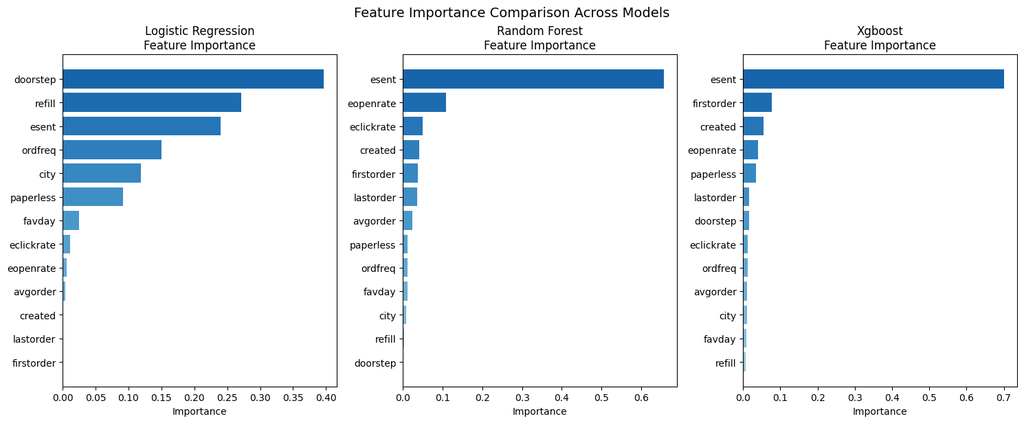

```
======================================================================
TOP 5 FEATURES BY MODEL
======================================================================

logistic_regression:
  doorstep             0.3965
  refill               0.2711
  esent                0.2395
  ordfreq              0.1503
  city                 0.1187

random_forest:
  esent                0.6571
  eopenrate            0.1086
  eclickrate           0.0492
  created              0.0413
  firstorder           0.0374

xgboost:
  esent                0.7009
  firstorder           0.0770
  created              0.0548
  eopenrate            0.0397
  paperless            0.0341
```

```python
def get_feature_importance(model, feature_names):
    """Extract feature importance from model."""
    if hasattr(model, 'feature_importances_'):
        return pd.DataFrame({
            'feature': feature_names,
            'importance': model.feature_importances_
        }).sort_values('importance', ascending=False)
    elif hasattr(model, 'coef_'):
        return pd.DataFrame({
            'feature': feature_names,
            'importance': np.abs(model.coef_[0])
        }).sort_values('importance', ascending=False)
    return None

# Get feature importance for each model
fig, axes = plt.subplots(1, len(models), figsize=(5*len(models), 6))

for i, (name, data) in enumerate(models.items()):
    model = data["model"]
    model_features = get_model_feature_names(model)
    fi = get_feature_importance(model, model_features)

    if fi is not None:
        ax = axes[i] if len(models) > 1 else axes
        colors = plt.cm.Blues(np.linspace(0.4, 0.8, len(fi)))
        ax.barh(fi['feature'], fi['importance'], color=colors[::-1])
        ax.set_xlabel('Importance')
        ax.set_title(f"{name.replace('_', ' ').title()}\nFeature Importance")
        ax.invert_yaxis()

plt.tight_layout()
plt.suptitle("Feature Importance Comparison Across Models", y=1.02, fontsize=14)
plt.show()

# Show top features table
print("\n" + "=" * 70)
print("TOP 5 FEATURES BY MODEL")
print("=" * 70)
for name, data in models.items():
    model = data["model"]
    model_features = get_model_feature_names(model)
    fi = get_feature_importance(model, model_features)
    if fi is not None:
        print(f"\n{name}:")
        for idx, row in fi.head(5).iterrows():
            print(f"  {row['feature']:20} {row['importance']:.4f}")
```

## 12. SHAP Analysis

SHAP (SHapley Additive exPlanations) values show how each feature contributes to individual predictions.

**Show/Hide Code**

```python
import shap

# Use best model for SHAP analysis (typically XGBoost or Random Forest)
best_model_name = best_model[0]
best_model_obj = models[best_model_name]["model"]

print(f"Creating SHAP explainer for {best_model_name}...")

# Prepare features for SHAP
X_shap = prepare_features_for_model(scoring_df, best_model_obj)

# Sample for faster computation if dataset is large
sample_size = min(500, len(X_shap))
X_sample = X_shap.sample(n=sample_size, random_state=42)

# Create appropriate explainer based on model type
if best_model_name == "xgboost":
    explainer = shap.TreeExplainer(best_model_obj)
elif best_model_name == "random_forest":
    explainer = shap.TreeExplainer(best_model_obj)
else:  # logistic_regression
    explainer = shap.LinearExplainer(best_model_obj, X_sample)

shap_values = explainer.shap_values(X_sample)

# Handle different SHAP value formats
if isinstance(shap_values, list):
    # For binary classification, use positive class
    shap_values = shap_values[1]

print(f"SHAP values computed for {sample_size} samples")
```

```
Creating SHAP explainer for logistic_regression...
SHAP values computed for 500 samples
```

**Show/Hide Code**

```
SHAP Summary Plot - Feature Impact on Predictions
============================================================
Red = high feature value, Blue = low feature value
Right = pushes toward retention, Left = pushes toward churn
```

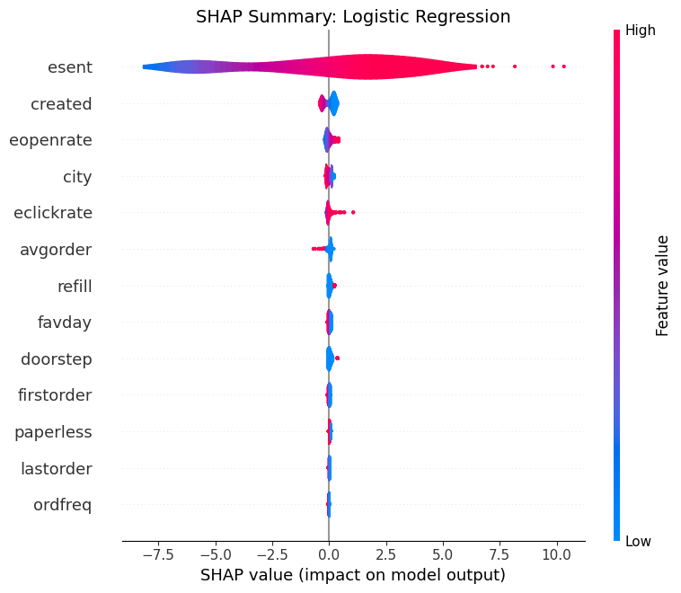

```python
# SHAP Summary Plot (Beeswarm)
print("SHAP Summary Plot - Feature Impact on Predictions")
print("=" * 60)
print("Red = high feature value, Blue = low feature value")
print("Right = pushes toward retention, Left = pushes toward churn")
print()

plt.figure(figsize=(10, 8))
shap.summary_plot(shap_values, X_sample, plot_type="violin", show=False)
plt.title(f"SHAP Summary: {best_model_name.replace('_', ' ').title()}", fontsize=14)
plt.tight_layout()
plt.show()
```

**Show/Hide Code**

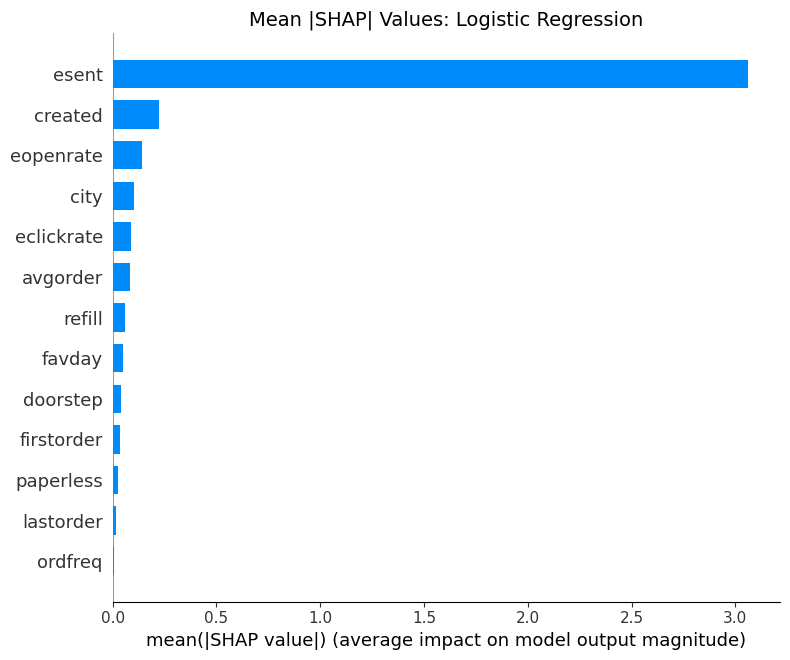

```
============================================================
SHAP FEATURE IMPORTANCE (Mean |SHAP|)
============================================================
  esent           3.0623 ██████████████████████████████
  created         0.2226 ██
  eopenrate       0.1432 █
  city            0.1015
  eclickrate      0.0869
  avgorder        0.0862
  refill          0.0585
  favday          0.0503
  doorstep        0.0398
  firstorder      0.0334
  paperless       0.0243
  lastorder       0.0144
  ordfreq         0.0072
```

```python
# SHAP Bar Plot - Mean absolute SHAP values
plt.figure(figsize=(10, 6))
shap.summary_plot(shap_values, X_sample, plot_type="bar", show=False)
plt.title(f"Mean |SHAP| Values: {best_model_name.replace('_', ' ').title()}", fontsize=14)
plt.tight_layout()
plt.show()

# Print interpretation
mean_abs_shap = np.abs(shap_values).mean(axis=0)
feature_importance_shap = pd.DataFrame({
    'feature': X_sample.columns,
    'mean_abs_shap': mean_abs_shap
}).sort_values('mean_abs_shap', ascending=False)

print("\n" + "=" * 60)
print("SHAP FEATURE IMPORTANCE (Mean |SHAP|)")
print("=" * 60)
for idx, row in feature_importance_shap.iterrows():
    bar_len = int(row['mean_abs_shap'] / feature_importance_shap['mean_abs_shap'].max() * 30)
    bar = "█" * bar_len
    print(f"  {row['feature']:15} {row['mean_abs_shap']:.4f} {bar}")
```

### Individual Prediction Explanations

Waterfall plots showing how features contribute to specific predictions.

**Show/Hide Code**

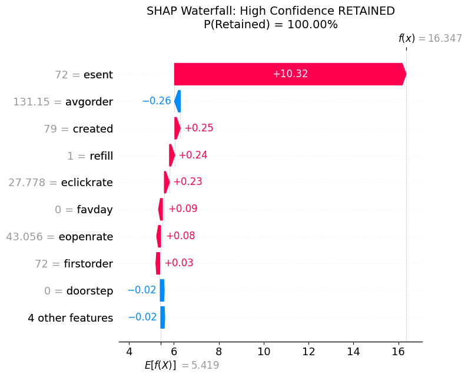

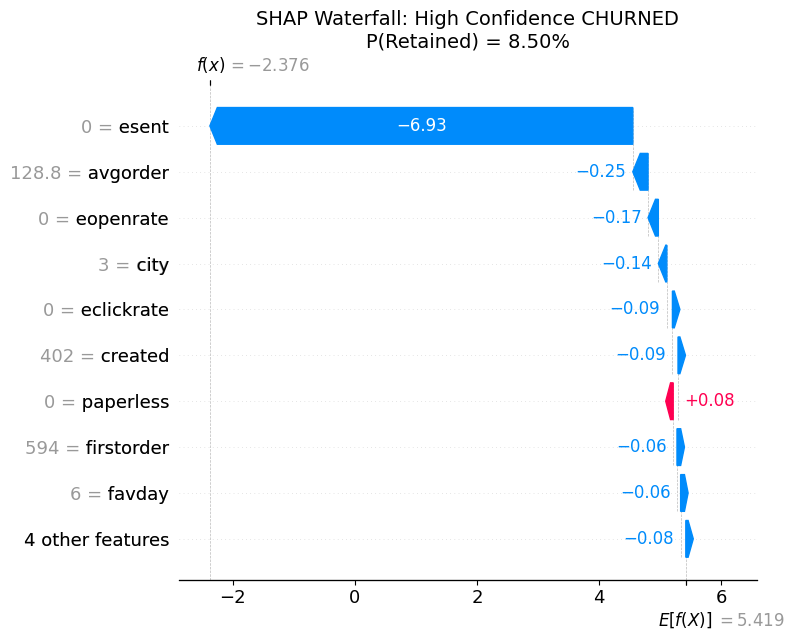

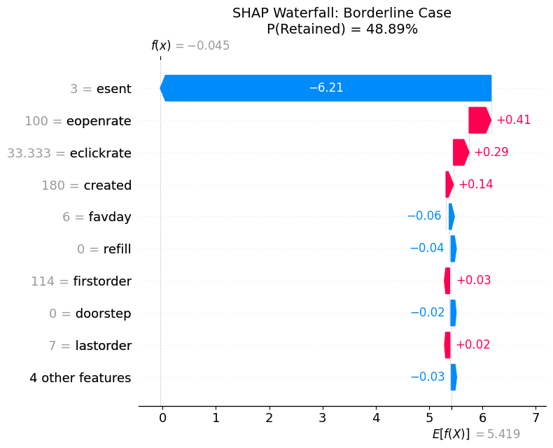

```python
# Show waterfall plots for a few example predictions
# Find indices for: high confidence retained, high confidence churned, borderline case
y_proba_sample = best_model_obj.predict_proba(X_sample)[:, 1]

high_retain_idx = np.argmax(y_proba_sample)  # Most likely to be retained
high_churn_idx = np.argmin(y_proba_sample)   # Most likely to churn
borderline_idx = np.argmin(np.abs(y_proba_sample - 0.5))  # Closest to 0.5

examples = [
    ("High Confidence RETAINED", high_retain_idx, y_proba_sample[high_retain_idx]),
    ("High Confidence CHURNED", high_churn_idx, y_proba_sample[high_churn_idx]),
    ("Borderline Case", borderline_idx, y_proba_sample[borderline_idx])
]

# Get base value for SHAP explanations
if hasattr(explainer, 'expected_value'):
    if isinstance(explainer.expected_value, (list, np.ndarray)):
        base_value = explainer.expected_value[1] if len(explainer.expected_value) > 1 else explainer.expected_value[0]
    else:
        base_value = explainer.expected_value
else:
    base_value = 0

# Create separate waterfall plot for each example
for title, idx, prob in examples:
    fig, ax = plt.subplots(figsize=(10, 6))

    explanation = shap.Explanation(
        values=shap_values[idx],
        base_values=base_value,
        data=X_sample.iloc[idx].values,
        feature_names=list(X_sample.columns)
    )

    shap.waterfall_plot(explanation, show=False, max_display=10)
    plt.title(f"SHAP Waterfall: {title}\nP(Retained) = {prob:.2%}", fontsize=14)
    plt.tight_layout()
    plt.show()
```

### SHAP Dependence Plots

How individual features affect predictions across their value range.

**Show/Hide Code**

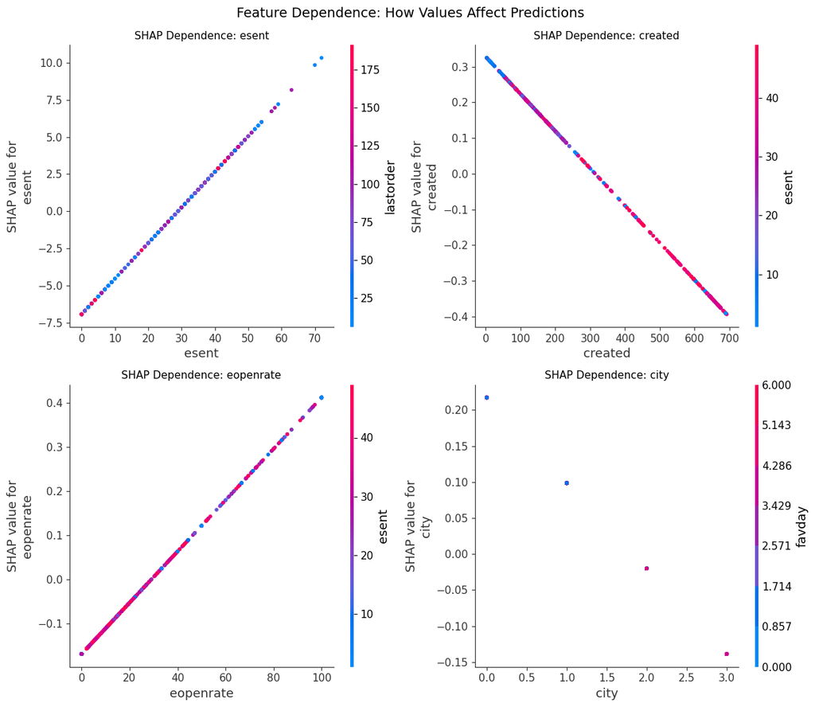

```
Interpretation:
  • X-axis: Feature value
  • Y-axis: SHAP value (contribution to prediction)
  • Color: Interaction with another feature
  • Positive SHAP = pushes toward retention
  • Negative SHAP = pushes toward churn
```

```python
# Dependence plots for top 4 features
top_features = feature_importance_shap.head(4)['feature'].tolist()

fig, axes = plt.subplots(2, 2, figsize=(12, 10))
axes = axes.flatten()

for i, feature in enumerate(top_features):
    plt.sca(axes[i])
    shap.dependence_plot(
        feature,
        shap_values,
        X_sample,
        interaction_index="auto",
        show=False,
        ax=axes[i]
    )
    axes[i].set_title(f"SHAP Dependence: {feature}", fontsize=11)

plt.tight_layout()
plt.suptitle("Feature Dependence: How Values Affect Predictions", y=1.02, fontsize=14)
plt.show()

print("\nInterpretation:")
print("  • X-axis: Feature value")
print("  • Y-axis: SHAP value (contribution to prediction)")
print("  • Color: Interaction with another feature")
print("  • Positive SHAP = pushes toward retention")
print("  • Negative SHAP = pushes toward churn")
```

### Partial Dependence Plots (PDP)

PDPs show the **average effect** of a feature on predictions, making the main relationship clearer without interaction effects.

**Show/Hide Code**

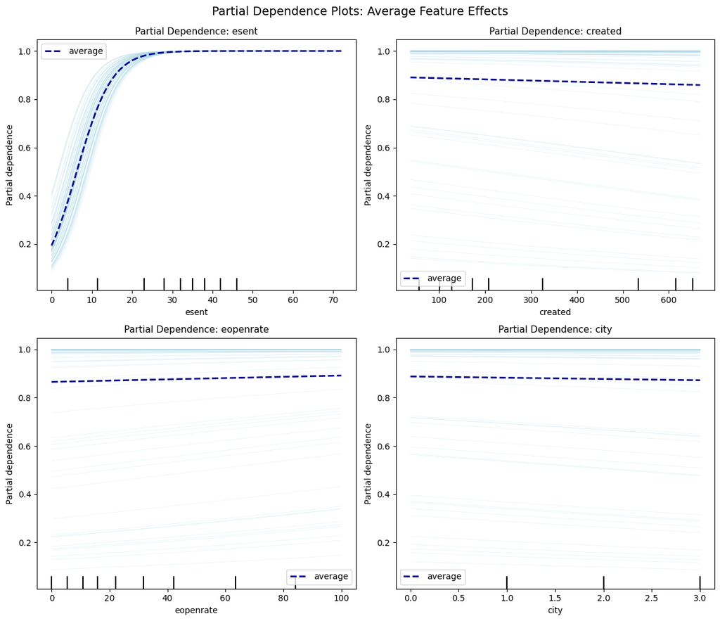

```
Interpretation:
  • Light blue lines: Individual Conditional Expectation (ICE) - each sample's prediction curve
  • Dark blue line: Partial Dependence Plot (PDP) - average effect across all samples
  • Y-axis: Predicted probability of retention
  • Steep slopes indicate strong feature influence on predictions
  • Flat regions indicate feature values with minimal impact
```

```python
from sklearn.inspection import PartialDependenceDisplay

# Create Partial Dependence Plots for top 4 features
fig, axes = plt.subplots(2, 2, figsize=(12, 10))

# Get feature indices for top features
feature_indices = [list(X_sample.columns).index(f) for f in top_features]

PartialDependenceDisplay.from_estimator(
    best_model_obj,
    X_sample,
    features=feature_indices,
    feature_names=list(X_sample.columns),
    ax=axes.flatten(),
    kind='both',  # Shows both individual (ICE) lines and average (PDP)
    subsample=100,
    random_state=42,
    ice_lines_kw={'color': 'lightblue', 'alpha': 0.3, 'linewidth': 0.5},
    pd_line_kw={'color': 'darkblue', 'linewidth': 2}
)

for ax, feature in zip(axes.flatten(), top_features):
    ax.set_title(f"Partial Dependence: {feature}", fontsize=11)

plt.tight_layout()
plt.suptitle("Partial Dependence Plots: Average Feature Effects", y=1.02, fontsize=14)
plt.show()

print("\nInterpretation:")
print("  • Light blue lines: Individual Conditional Expectation (ICE) - each sample's prediction curve")
print("  • Dark blue line: Partial Dependence Plot (PDP) - average effect across all samples")
print("  • Y-axis: Predicted probability of retention")
print("  • Steep slopes indicate strong feature influence on predictions")
print("  • Flat regions indicate feature values with minimal impact")
```

## 13. Model Interpretability Summary

**Show/Hide Code**

```python
print("=" * 80)
print("MODEL INTERPRETABILITY SUMMARY")
print("=" * 80)

print(f"\n📊 Model Analyzed: {best_model_name.replace('_', ' ').title()}")
print(f"   Scoring ROC-AUC: {best_score_auc:.4f}")

print(f"\n🔑 TOP PREDICTIVE FEATURES (by SHAP importance):")
for i, (_, row) in enumerate(feature_importance_shap.head(5).iterrows(), 1):
    print(f"   {i}. {row['feature']:15} (Mean |SHAP| = {row['mean_abs_shap']:.4f})")

# Analyze feature directions
print(f"\n📈 FEATURE EFFECTS:")
for feature in feature_importance_shap.head(5)['feature']:
    feat_idx = list(X_sample.columns).index(feature)
    correlation = np.corrcoef(X_sample[feature].values, shap_values[:, feat_idx])[0, 1]
    direction = "Higher values → MORE retention" if correlation > 0 else "Higher values → LESS retention"
    print(f"   • {feature}: {direction}")

print(f"\n💡 KEY INSIGHTS:")
print(f"   • The model uses {len(feature_names)} features for predictions")
print(f"   • Top 3 features account for {feature_importance_shap.head(3)['mean_abs_shap'].sum() / feature_importance_shap['mean_abs_shap'].sum() * 100:.1f}% of prediction impact")
print(f"   • Email engagement features (eopenrate, eclickrate) show significant drift")
print(f"   • Consider monitoring these features for model degradation")

print("\n" + "=" * 80)
print("END OF SCORING DASHBOARD")
print("=" * 80)
```

```
================================================================================
MODEL INTERPRETABILITY SUMMARY
================================================================================

📊 Model Analyzed: Logistic Regression
   Scoring ROC-AUC: 0.9441

🔑 TOP PREDICTIVE FEATURES (by SHAP importance):
   1. esent           (Mean |SHAP| = 3.0623)
   2. created         (Mean |SHAP| = 0.2226)
   3. eopenrate       (Mean |SHAP| = 0.1432)
   4. city            (Mean |SHAP| = 0.1015)
   5. eclickrate      (Mean |SHAP| = 0.0869)

📈 FEATURE EFFECTS:
   • esent: Higher values → MORE retention
   • created: Higher values → LESS retention
   • eopenrate: Higher values → MORE retention
   • city: Higher values → LESS retention
   • eclickrate: Higher values → MORE retention

💡 KEY INSIGHTS:
   • The model uses 13 features for predictions
   • Top 3 features account for 87.2% of prediction impact
   • Email engagement features (eopenrate, eclickrate) show significant drift
   • Consider monitoring these features for model degradation

================================================================================
END OF SCORING DASHBOARD
================================================================================
```